# Prediction on Crime Rate using Linear Regression

Ichlasul Amal

January 12, 2021

# 1 Objektif

Pada artikel ini, dilakukan penerapan algoritma Regresi Linear untuk memprediksi tingkat kejahatan (`crime_rate`). Dataset yang digunakan berasal dari setiap negara bagian di Amerika Serikat dan diambil pada tahun 1960. Regresi Linear dapat digunakan untuk memprediksi tingkat kejahatan dan mengetahui variabel apa saja yang signifikan berpengaruh terhadap tingkat kejahatan.

# 2 Persiapan Data dan Exploratory Data Analysis

Melakukan read dataset yang akan digunakan dalam analisis

```r
crime <- read.csv("data_input/crime.csv")
head(crime)
```

|  | X | M | So | Ed | Po1 | Po2 | LF | M.F | Pop | NW | U1 | U2 | GDP | Ineq | Prob | Time | y |
| --- | --- | --- | --- | --- | --- | --- | --- | --- | --- | --- | --- | --- | --- | --- | --- | --- | --- |
| 1 | 1 | 151 | 1 | 91 | 58 | 56 | 510 | 950 | 33 | 301 | 108 | 41 | 394 | 261 | 0.084602 | 26.2011 | 791 |
| 2 | 2 | 143 | 0 | 113 | 103 | 95 | 583 | 1012 | 13 | 102 | 96 | 36 | 557 | 194 | 0.029599 | 25.2999 | 1635 |
| 3 | 3 | 142 | 1 | 89 | 45 | 44 | 533 | 969 | 18 | 219 | 94 | 33 | 318 | 250 | 0.083401 | 24.3006 | 578 |
| 4 | 4 | 136 | 0 | 121 | 149 | 141 | 577 | 994 | 157 | 80 | 102 | 39 | 673 | 167 | 0.015801 | 29.9012 | 1969 |
| 5 | 5 | 141 | 0 | 121 | 109 | 101 | 591 | 985 | 18 | 30 | 91 | 20 | 578 | 174 | 0.041399 | 21.2998 | 1234 |
| 6 | 6 | 121 | 0 | 110 | 118 | 115 | 547 | 964 | 25 | 44 | 84 | 29 | 689 | 126 | 0.034201 | 20.9995 | 682 |

Setelah dilakukan read data, nama kolom masih sulit untuk dimengerti karena berupa singkatan, sehingga diubah menjadi seperti di bawah ini

```r
names(crime) <- c("X" ,"percent_m", "is_south", "mean_education", "police_exp60", "police_exp59", "labour_participation", "m_per1000f", "state_pop", "nonwhites_per1000", "unemploy_m24", "unemploy_m39", "gdp", "inequality", "prob_prison", "time_prison", "crime_rate")
crime
```

| X | percent_m | is_south | mean_education | police_exp60 | police_exp59 | labour_participation | m_per1000f | state_pop | nonwhites_per1000 | unemploy_m24 | unemploy_m39 | gdp | inequality | prob_prison | time_prison | crime_rate |
| --- | --- | --- | --- | --- | --- | --- | --- | --- | --- | --- | --- | --- | --- | --- | --- | --- |
| 1 | 151 | 1 | 91 | 58 | 56 | 510 | 950 | 33 | 301 | 108 | 41 | 394 | 261 | 0.084602 | 26.2011 | 791 |
| 2 | 143 | 0 | 113 | 103 | 95 | 583 | 1012 | 13 | 102 | 96 | 36 | 557 | 194 | 0.029599 | 25.2999 | 1635 |
| 3 | 142 | 1 | 89 | 45 | 44 | 533 | 969 | 18 | 219 | 94 | 33 | 318 | 250 | 0.083401 | 24.3006 | 578 |
| 4 | 136 | 0 | 121 | 149 | 141 | 577 | 994 | 157 | 80 | 102 | 39 | 673 | 167 | 0.015801 | 29.9012 | 1969 |
| 5 | 141 | 0 | 121 | 109 | 101 | 591 | 985 | 18 | 30 | 91 | 20 | 578 | 174 | 0.041399 | 21.2998 | 1234 |
| 6 | 121 | 0 | 110 | 118 | 115 | 547 | 964 | 25 | 44 | 84 | 29 | 689 | 126 | 0.034201 | 20.9995 | 682 |
| 7 | 127 | 1 | 111 | 82 | 79 | 519 | 982 | 4 | 139 | 97 | 38 | 620 | 168 | 0.042100 | 20.6993 | 963 |
| 8 | 131 | 1 | 109 | 115 | 109 | 542 | 969 | 50 | 179 | 79 | 35 | 472 | 206 | 0.040099 | 24.5988 | 1555 |
| 9 | 157 | 1 | 90 | 65 | 62 | 553 | 955 | 39 | 286 | 81 | 28 | 421 | 239 | 0.071697 | 29.4001 | 856 |
| 10 | 140 | 0 | 118 | 71 | 68 | 632 | 1029 | 7 | 15 | 100 | 24 | 526 | 174 | 0.044498 | 19.5994 | 705 |

[output cut: 37 more lines]

Dataset ini berasal dari tiap negara bagian di Amerika Serikat, diambil pada tahun 1960. Penjelasan dari tiap kolom pada dataset sebagai berikut:

- `persen_m`: persentase laki-laki berusia 14-24
- `is_south`: apakah berada di negara bagian Selatan. 1 untuk Ya, 0 untuk Tidak.
- `mean_education`: rata-rata tahun sekolah
- `police_exp60`: pengeluaran polisi tahun 1960
- `police_exp59`: pengeluaran polisi tahun 1959
- `labour_participation`: tingkat partisipasi angkatan kerja
- `m_per1000f`: jumlah pria per 1000 wanita
- `state_pop`: populasi negara bagian
- `nonwhites_per1000`: jumlah penduduk non-kulit putih per 1000 orang
- `unemploy_m24`: tingkat pengangguran pria perkotaan berusia 14-24 tahun
- `unemploy_m39`: tingkat pengangguran laki-laki perkotaan berusia 35-39 tahun
- `gdp`: produk domestik bruto per kapita
- `inequality`: ketimpangan pendapatan
- `prob_prison`: kemungkinan hukuman penjara
- `time_prison`: waktu rata-rata hukuman di penjara
- `crime_rate`: tingkat kejahatan dalam kategori yang tidak ditentukan

Dilakukan pengecekan pada struktur data

```r
library(dplyr)
glimpse(crime)
```

```
#> Rows: 47
#> Columns: 17
#> $ X                    <int> 1, 2, 3, 4, 5, 6, 7, 8, 9, 10, 11, 12, 13, 14,...
#> $ percent_m            <int> 151, 143, 142, 136, 141, 121, 127, 131, 157, 1...
#> $ is_south             <int> 1, 0, 1, 0, 0, 0, 1, 1, 1, 0, 0, 0, 0, 0, 1, 1...
#> $ mean_education       <int> 91, 113, 89, 121, 121, 110, 111, 109, 90, 118,...
#> $ police_exp60         <int> 58, 103, 45, 149, 109, 118, 82, 115, 65, 71, 1...
#> $ police_exp59         <int> 56, 95, 44, 141, 101, 115, 79, 109, 62, 68, 11...
#> $ labour_participation <int> 510, 583, 533, 577, 591, 547, 519, 542, 553, 6...
#> $ m_per1000f           <int> 950, 1012, 969, 994, 985, 964, 982, 969, 955, ...
#> $ state_pop            <int> 33, 13, 18, 157, 18, 25, 4, 50, 39, 7, 101, 47...
#> $ nonwhites_per1000    <int> 301, 102, 219, 80, 30, 44, 139, 179, 286, 15, ...
#> $ unemploy_m24         <int> 108, 96, 94, 102, 91, 84, 97, 79, 81, 100, 77,...
#> $ unemploy_m39         <int> 41, 36, 33, 39, 20, 29, 38, 35, 28, 24, 35, 31...
#> $ gdp                  <int> 394, 557, 318, 673, 578, 689, 620, 472, 421, 5...
#> $ inequality           <int> 261, 194, 250, 167, 174, 126, 168, 206, 239, 1...
#> $ prob_prison          <dbl> 0.084602, 0.029599, 0.083401, 0.015801, 0.0413...
#> $ time_prison          <dbl> 26.2011, 25.2999, 24.3006, 29.9012, 21.2998, 2...
#> $ crime_rate           <int> 791, 1635, 578, 1969, 1234, 682, 963, 1555, 85...
```

Tipe kolom `is_south` adalah integer sehingga belum tepat, karena seharusnya bertipe factor, kemudian dilakukan pengubahan menjadi bertipe factor. Selain itu, kolom `X` akan dihapus, karena kolom tersebut berisi nomor dari tiap baris, sehingga tidak dibutuhkan dalam analisis.

```r
crime <- crime %>%
  select(-X) %>%
  mutate(is_south = as.factor(is_south))
crime
```

| percent_m | is_south | mean_education | police_exp60 | police_exp59 | labour_participation | m_per1000f | state_pop | nonwhites_per1000 | unemploy_m24 | unemploy_m39 | gdp | inequality | prob_prison | time_prison | crime_rate |
| --- | --- | --- | --- | --- | --- | --- | --- | --- | --- | --- | --- | --- | --- | --- | --- |
| 151 | 1 | 91 | 58 | 56 | 510 | 950 | 33 | 301 | 108 | 41 | 394 | 261 | 0.084602 | 26.2011 | 791 |
| 143 | 0 | 113 | 103 | 95 | 583 | 1012 | 13 | 102 | 96 | 36 | 557 | 194 | 0.029599 | 25.2999 | 1635 |
| 142 | 1 | 89 | 45 | 44 | 533 | 969 | 18 | 219 | 94 | 33 | 318 | 250 | 0.083401 | 24.3006 | 578 |
| 136 | 0 | 121 | 149 | 141 | 577 | 994 | 157 | 80 | 102 | 39 | 673 | 167 | 0.015801 | 29.9012 | 1969 |
| 141 | 0 | 121 | 109 | 101 | 591 | 985 | 18 | 30 | 91 | 20 | 578 | 174 | 0.041399 | 21.2998 | 1234 |
| 121 | 0 | 110 | 118 | 115 | 547 | 964 | 25 | 44 | 84 | 29 | 689 | 126 | 0.034201 | 20.9995 | 682 |
| 127 | 1 | 111 | 82 | 79 | 519 | 982 | 4 | 139 | 97 | 38 | 620 | 168 | 0.042100 | 20.6993 | 963 |
| 131 | 1 | 109 | 115 | 109 | 542 | 969 | 50 | 179 | 79 | 35 | 472 | 206 | 0.040099 | 24.5988 | 1555 |
| 157 | 1 | 90 | 65 | 62 | 553 | 955 | 39 | 286 | 81 | 28 | 421 | 239 | 0.071697 | 29.4001 | 856 |
| 140 | 0 | 118 | 71 | 68 | 632 | 1029 | 7 | 15 | 100 | 24 | 526 | 174 | 0.044498 | 19.5994 | 705 |

[output cut: 37 more lines]

Dilakukan cek apakah terdapat missing value pada dataset

```r
colSums(is.na(crime))
```

```
#>            percent_m             is_south       mean_education
#>                    0                    0                    0
#>         police_exp60         police_exp59 labour_participation
#>                    0                    0                    0
#>           m_per1000f            state_pop    nonwhites_per1000
#>                    0                    0                    0
#>         unemploy_m24         unemploy_m39                  gdp
#>                    0                    0                    0
#>           inequality          prob_prison          time_prison
#>                    0                    0                    0
#>           crime_rate
#>                    0
```

Selanjutnya dicek bagaimana korelasi antar variabel

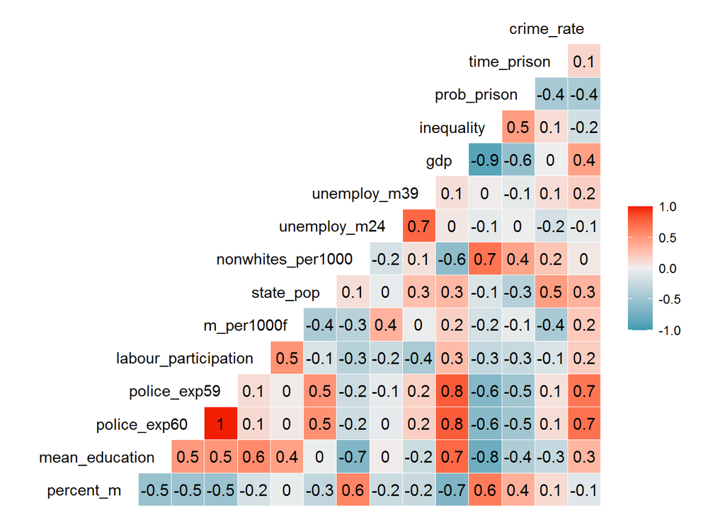

```r
library(GGally)
ggcorr(crime,label=T, layout.exp=2, hjust= 1)
```

Pada grafik korelasi di atas, korelasi antara variabel `crime_rate` dan variabel prediktor bervariasi, ada yang berkorelasi positif dan berkorelasi negatif. Variabel `police_exp59` dan `police_exp60` memiliki korelasi **kuat** terhadap `crime_rate`. Variabel `gdp` berkorelasi **sedang** terhadap `crime_rate`. Variabel `nonwhites_per1000`, `time_prison`, `unemploy_m24`, dan `percent_m` berkorelasi **sangat rendah** terhadap `crime_rate`, dan variabel prediktor sisanya berkorelasi **rendah** terhadap `crime_rate`.

Langkah selanjutnya adalah cek distribusi pada variabel yang bertipe numerik

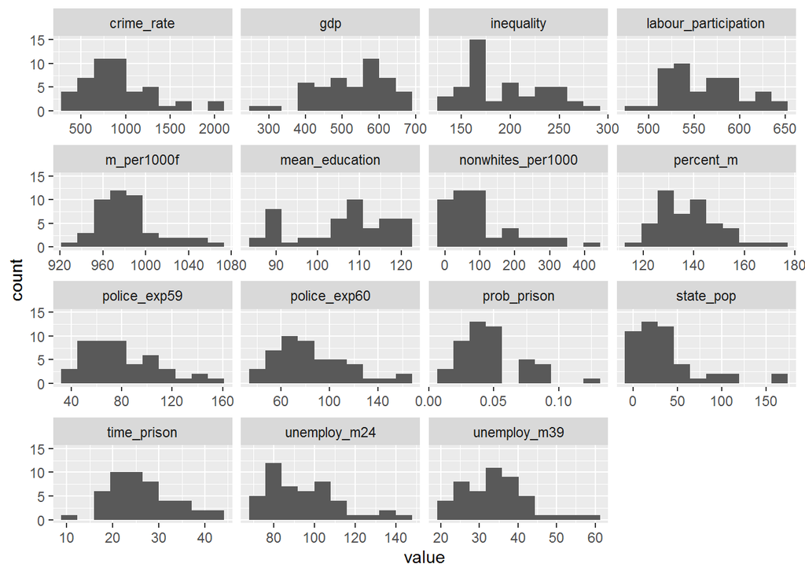

```r
library(tidyr)
ggplot(gather(crime %>% select_if(is.numeric)), aes(value)) +
    geom_histogram(bins = 10) +
    facet_wrap(~key, scales = 'free_x')
```

# 3 Pembuatan Model

Sebelum dilakukan pemodelan, terlebih dahulu dilakukan split pada data menjadi data train dan data test. Proporsi untuk data train dan data test adalah 70:30.

```r
set.seed(123)
samplesize <- round(0.7 * nrow(crime), 0)
index <- sample(seq_len(nrow(crime)), size = samplesize)

data_train <- crime[index, ]
data_test <- crime[-index, ]
```

Sebagai model baseline, akan digunakan semua variabel prediktor untuk pembuatan model

```r
model_all <- lm(formula = crime_rate ~ ., data = data_train)
summary(model_all)
```

```
#>
#> Call:
#> lm(formula = crime_rate ~ ., data = data_train)
#>
#> Residuals:
#>     Min      1Q  Median      3Q     Max
#> -304.71  -91.82  -31.14  101.84  426.16
#>
#> Coefficients:
#>                         Estimate  Std. Error t value Pr(>|t|)
#> (Intercept)          -10332.3968   2232.6587  -4.628  0.00024 ***
#> percent_m                 9.6677      4.4748   2.160  0.04530 *
#> is_south1                 8.1011    223.3111   0.036  0.97148
#> mean_education           26.2959      7.6978   3.416  0.00329 **
#> police_exp60             20.0908     11.8628   1.694  0.10858
#> police_exp59            -14.8569     13.5366  -1.098  0.28771
#> labour_participation     -4.6592      2.1721  -2.145  0.04669 *
#> m_per1000f                8.2657      2.8606   2.889  0.01019 *
#> state_pop                 1.3699      1.7925   0.764  0.45521
#> nonwhites_per1000         1.3334      0.9991   1.335  0.19960
#> unemploy_m24            -11.9795      5.1323  -2.334  0.03212 *
#> unemploy_m39             14.2389      9.8688   1.443  0.16724
#> gdp                       0.6436      1.2624   0.510  0.61671
#> inequality                4.2472      2.8552   1.488  0.15518
#> prob_prison             940.1481   3823.0185   0.246  0.80869
#> time_prison              14.7756      9.4304   1.567  0.13558
#> ---
#> Signif. codes:  0 '***' 0.001 '**' 0.01 '*' 0.05 '.' 0.1 ' ' 1
#>
#> Residual standard error: 199.9 on 17 degrees of freedom
#> Multiple R-squared:  0.8813, Adjusted R-squared:  0.7766
#> F-statistic: 8.414 on 15 and 17 DF,  p-value: 0.00003846
```

Dari summary model, dapat dinyatakan bahwa:

- pada taraf signifikansi 0.05, variabel `percent_m`, `mean_education`, `labour_participation`, `m_per1000f` dan `unemploy_m24` berpengaruh signifikan terhadap `crime_rate`
- pada uji kecocokan model, didapatkan p-value kurang dari 0.05 sehingga model dinyatakan cocok dalam menyatakan hubungan variabel-variabel prediktor terhadap variabel target yaitu `crime_rate`
- model yang dibuat menggambarkan 77.66% informasi dari `crime_rate`, sedangkan sisanya yaitu 22.34% dipengaruhi variabel lain diluar model

## 3.1 Model Tuning

Model yang dibuat masih terdapat beberapa variabel yang tidak berpengaruh signifikan terhadap variabel target. Dilakukan `stepwise regression` untuk memilih variabel terbaik.

```r
model_none <- lm(crime_rate ~ 1, data = data_train)
```

### 3.1.1 Metode Backward

```r
model_backward <- step(object = model_all, direction = "backward")
```

```
#> Start:  AIC=359.75
#> crime_rate ~ percent_m + is_south + mean_education + police_exp60 +
#>     police_exp59 + labour_participation + m_per1000f + state_pop +
#>     nonwhites_per1000 + unemploy_m24 + unemploy_m39 + gdp + inequality +
#>     prob_prison + time_prison
#>
#>                        Df Sum of Sq     RSS    AIC
#> - is_south              1        53  679085 357.76
#> - prob_prison           1      2416  681448 357.87
#> - gdp                   1     10383  689416 358.25
#> - state_pop             1     23329  702361 358.87
#> <none>                               679033 359.75
#> - police_exp59          1     48115  727148 360.01
#> - nonwhites_per1000     1     71147  750179 361.04
#> - unemploy_m39          1     83151  762184 361.57
#> - inequality            1     88386  767419 361.79
#> - time_prison           1     98056  777088 362.20
#> - police_exp60          1    114569  793601 362.90
#> - labour_participation  1    183780  862813 365.66
#> - percent_m             1    186444  865477 365.76
#> - unemploy_m24          1    217618  896650 366.93
#> - m_per1000f            1    333491 1012523 370.94
#> - mean_education        1    466102 1145135 375.00
#>
#> Step:  AIC=357.76
#> crime_rate ~ percent_m + mean_education + police_exp60 + police_exp59 +
#>     labour_participation + m_per1000f + state_pop + nonwhites_per1000 +
#>     unemploy_m24 + unemploy_m39 + gdp + inequality + prob_prison +
#>     time_prison
#>
#>                        Df Sum of Sq     RSS    AIC
#> - prob_prison           1      2364  681450 355.87
#> - gdp                   1     11061  690146 356.29
#> - state_pop             1     24951  704037 356.95
#> <none>                               679085 357.76
#> - police_exp59          1     48985  728070 358.05
#> - unemploy_m39          1     89682  768768 359.85
#> - time_prison           1    100182  779268 360.30
#> - police_exp60          1    115574  794659 360.94
#> - nonwhites_per1000     1    136646  815731 361.81
```

[output cut: 69 more lines]

```
#>     m_per1000f + nonwhites_per1000 + unemploy_m24 + unemploy_m39 +
#>     inequality + time_prison
#>
#>                        Df Sum of Sq     RSS    AIC
#> <none>                               754102 353.21
#> - nonwhites_per1000     1    112421  866523 355.80
#> - unemploy_m39          1    123900  878001 356.23
#> - percent_m             1    156886  910987 357.45
#> - labour_participation  1    182728  936829 358.37
#> - unemploy_m24          1    231604  985706 360.05
#> - inequality            1    249087 1003189 360.63
#> - time_prison           1    262614 1016716 361.07
#> - m_per1000f            1    405612 1159714 365.42
#> - mean_education        1    579494 1333596 370.03
#> - police_exp60          1    765063 1519165 374.33
```

```r
summary(model_backward)
```

```
#>
#> Call:
#> lm(formula = crime_rate ~ percent_m + mean_education + police_exp60 +
#>     labour_participation + m_per1000f + nonwhites_per1000 + unemploy_m24 +
#>     unemploy_m39 + inequality + time_prison, data = data_train)
#>
#> Residuals:
#>     Min      1Q  Median      3Q     Max
#> -283.69  -80.50  -16.92   82.84  429.87
#>
#> Coefficients:
#>                        Estimate Std. Error t value   Pr(>|t|)
#> (Intercept)          -9643.5294  1570.9487  -6.139 0.00000353 ***
#> percent_m                8.3543     3.9050   2.139   0.043752 *
#> mean_education          25.3573     6.1671   4.112   0.000459 ***
#> police_exp60             8.3365     1.7646   4.724   0.000103 ***
#> labour_participation    -3.5144     1.5221  -2.309   0.030727 *
#> m_per1000f               7.1285     2.0723   3.440   0.002337 **
#> nonwhites_per1000        1.1725     0.6474   1.811   0.083817 .
#> unemploy_m24           -10.2895     3.9585  -2.599   0.016368 *
#> unemploy_m39            16.0240     8.4283   1.901   0.070453 .
#> inequality               4.6137     1.7115   2.696   0.013205 *
#> time_prison             15.7576     5.6929   2.768   0.011222 *
#> ---
#> Signif. codes:  0 '***' 0.001 '**' 0.01 '*' 0.05 '.' 0.1 ' ' 1
#>
#> Residual standard error: 185.1 on 22 degrees of freedom
#> Multiple R-squared:  0.8682, Adjusted R-squared:  0.8082
#> F-statistic: 14.49 on 10 and 22 DF,  p-value: 0.0000001705
```

Hasil summary dari model backward, variabel `nonwhites_per1000` tidak berpengaruh signifikan terhadap `crime_rate` karena p-value yang cukup besar pada uji t yaitu 0.083817 dan lebih besar alpha = 0.05. Sehingga variabel `nonwhites_per1000` akan coba dihapus dari pembuatan model.

```r
model_backward_sig <- lm(formula = crime_rate ~ percent_m + mean_education +
                           police_exp60 + labour_participation + m_per1000f + unemploy_m24 +
                           unemploy_m39 + inequality + time_prison, data = data_train)
summary(model_backward_sig)
```

```
#>
#> Call:
#> lm(formula = crime_rate ~ percent_m + mean_education + police_exp60 +
#>     labour_participation + m_per1000f + unemploy_m24 + unemploy_m39 +
#>     inequality + time_prison, data = data_train)
#>
#> Residuals:
#>     Min      1Q  Median      3Q     Max
#> -311.71  -84.46   -6.46  114.52  454.64
#>
#> Coefficients:
#>                       Estimate Std. Error t value   Pr(>|t|)
#> (Intercept)          -9471.069   1643.937  -5.761 0.00000721 ***
#> percent_m               11.252      3.735   3.013    0.00620 **
#> mean_education          22.617      6.268   3.608    0.00148 **
#> police_exp60             9.667      1.682   5.748 0.00000745 ***
#> labour_participation    -3.034      1.571  -1.931    0.06589 .
#> m_per1000f               6.405      2.132   3.005    0.00632 **
#> unemploy_m24           -11.069      4.125  -2.683    0.01328 *
#> unemploy_m39            17.352      8.803   1.971    0.06085 .
#> inequality               5.650      1.691   3.341    0.00284 **
#> time_prison             14.612      5.931   2.463    0.02167 *
#> ---
#> Signif. codes:  0 '***' 0.001 '**' 0.01 '*' 0.05 '.' 0.1 ' ' 1
#>
#> Residual standard error: 194.1 on 23 degrees of freedom
#> Multiple R-squared:  0.8485, Adjusted R-squared:  0.7892
#> F-statistic: 14.31 on 9 and 23 DF,  p-value: 0.0000001824
```

### 3.1.2 Metode Forward

```r
model_forward <- step(object = model_none, direction = "forward",
                      scope = list(lower=model_none, upper=model_all))
```

```
#> Start:  AIC=400.08
#> crime_rate ~ 1
#>
#>                        Df Sum of Sq     RSS    AIC
#> + police_exp60          1   3067509 2652830 376.72
#> + police_exp59          1   2936030 2784309 378.32
#> + gdp                   1   1438230 4282109 392.52
#> + prob_prison           1   1208195 4512144 394.25
#> + state_pop             1    863317 4857022 396.68
#> + mean_education        1    644363 5075976 398.14
#> + time_prison           1    342134 5378205 400.04
#> <none>                              5720339 400.08
#> + nonwhites_per1000     1    250813 5469526 400.60
#> + inequality            1    237199 5483139 400.68
#> + m_per1000f            1    232198 5488141 400.71
#> + labour_participation  1    130122 5590217 401.32
#> + unemploy_m39          1    128267 5592072 401.33
#> + unemploy_m24          1    106316 5614023 401.46
#> + percent_m             1     11241 5709098 402.02
#> + is_south              1      1342 5718997 402.07
#>
#> Step:  AIC=376.72
#> crime_rate ~ police_exp60
#>
#>                        Df Sum of Sq     RSS    AIC
#> + percent_m             1    584944 2067886 370.50
#> + inequality            1    503782 2149048 371.77
#> + nonwhites_per1000     1    419666 2233164 373.04
#> + is_south              1    405185 2247645 373.25
#> + m_per1000f            1    239626 2413204 375.60
#> <none>                              2652830 376.72
#> + labour_participation  1     72927 2579903 377.80
#> + gdp                   1     68380 2584450 377.86
#> + police_exp59          1     59345 2593485 377.98
#> + state_pop             1     40469 2612361 378.22
#> + unemploy_m24          1     26535 2626295 378.39
#> + time_prison           1     20992 2631838 378.46
#> + unemploy_m39          1      2025 2650805 378.70
#> + mean_education        1       533 2652297 378.72
#> + prob_prison           1       196 2652634 378.72
```

[output cut: 87 more lines]

```
#>
#> Step:  AIC=356.73
#> crime_rate ~ police_exp60 + percent_m + m_per1000f + is_south +
#>     mean_education + time_prison + inequality
#>
#>                        Df Sum of Sq     RSS    AIC
#> <none>                              1006039 356.73
#> + labour_participation  1     35364  970675 357.54
#> + unemploy_m39          1     33057  972983 357.62
#> + gdp                   1     10518  995521 358.38
#> + prob_prison           1      7291  998748 358.49
#> + state_pop             1      4712 1001328 358.57
#> + police_exp59          1      3856 1002184 358.60
#> + nonwhites_per1000     1      2703 1003336 358.64
#> + unemploy_m24          1       873 1005167 358.70
```

```r
summary(model_forward)
```

```
#>
#> Call:
#> lm(formula = crime_rate ~ police_exp60 + percent_m + m_per1000f +
#>     is_south + mean_education + time_prison + inequality, data = data_train)
#>
#> Residuals:
#>     Min      1Q  Median      3Q     Max
#> -363.98  -88.84   11.32   78.90  531.21
#>
#> Coefficients:
#>                 Estimate Std. Error t value    Pr(>|t|)
#> (Intercept)    -7901.441   1534.858  -5.148 0.000025425 ***
#> police_exp60      11.153      1.514   7.366 0.000000102 ***
#> percent_m          8.039      3.735   2.153     0.04120 *
#> m_per1000f         3.982      1.529   2.605     0.01526 *
#> is_south1        344.961    137.104   2.516     0.01866 *
#> mean_education    16.534      5.409   3.057     0.00527 **
#> time_prison       14.378      5.668   2.537     0.01781 *
#> inequality         3.039      1.957   1.553     0.13293
#> ---
#> Signif. codes:  0 '***' 0.001 '**' 0.01 '*' 0.05 '.' 0.1 ' ' 1
#>
#> Residual standard error: 200.6 on 25 degrees of freedom
#> Multiple R-squared:  0.8241, Adjusted R-squared:  0.7749
#> F-statistic: 16.74 on 7 and 25 DF,  p-value: 0.00000005419
```

Hasil summary dari model forward, variabel `inequality` tidak berpengaruh signifikan terhadap `crime_rate` karena p-value yang cukup besar pada uji t yaitu 0.13293 dan lebih besar alpha = 0.05. Sehingga variabel `inequality` akan coba dihapus dari pembuatan model.

```r
model_forward_sig <- lm(formula = crime_rate ~ police_exp60 + percent_m + m_per1000f +
                          is_south + mean_education + time_prison, data = data_train)
summary(model_forward_sig)
```

```
#>
#> Call:
#> lm(formula = crime_rate ~ police_exp60 + percent_m + m_per1000f +
#>     is_south + mean_education + time_prison, data = data_train)
#>
#> Residuals:
#>     Min      1Q  Median      3Q     Max
#> -326.64 -156.72    7.77  101.09  541.88
#>
#> Coefficients:
#>                 Estimate Std. Error t value    Pr(>|t|)
#> (Intercept)    -7771.882   1573.673  -4.939 0.000039506 ***
#> police_exp60      10.232      1.430   7.153 0.000000135 ***
#> percent_m          8.436      3.826   2.205    0.036491 *
#> m_per1000f         4.793      1.476   3.248    0.003199 **
#> is_south1        461.421    117.863   3.915    0.000583 ***
#> mean_education    13.074      5.061   2.583    0.015767 *
#> time_prison       14.838      5.812   2.553    0.016890 *
#> ---
#> Signif. codes:  0 '***' 0.001 '**' 0.01 '*' 0.05 '.' 0.1 ' ' 1
#>
#> Residual standard error: 206 on 26 degrees of freedom
#> Multiple R-squared:  0.8072, Adjusted R-squared:  0.7627
#> F-statistic: 18.14 on 6 and 26 DF,  p-value: 0.0000000361
```

### 3.1.3 Metode Both

```r
model_both1 <- step(object = model_all, direction = "both",
                    scope = list(lower=model_none, upper=model_all))
```

```
#> Start:  AIC=359.75
#> crime_rate ~ percent_m + is_south + mean_education + police_exp60 +
#>     police_exp59 + labour_participation + m_per1000f + state_pop +
#>     nonwhites_per1000 + unemploy_m24 + unemploy_m39 + gdp + inequality +
#>     prob_prison + time_prison
#>
#>                        Df Sum of Sq     RSS    AIC
#> - is_south              1        53  679085 357.76
#> - prob_prison           1      2416  681448 357.87
#> - gdp                   1     10383  689416 358.25
#> - state_pop             1     23329  702361 358.87
#> <none>                               679033 359.75
#> - police_exp59          1     48115  727148 360.01
#> - nonwhites_per1000     1     71147  750179 361.04
#> - unemploy_m39          1     83151  762184 361.57
#> - inequality            1     88386  767419 361.79
#> - time_prison           1     98056  777088 362.20
#> - police_exp60          1    114569  793601 362.90
#> - labour_participation  1    183780  862813 365.66
#> - percent_m             1    186444  865477 365.76
#> - unemploy_m24          1    217618  896650 366.93
#> - m_per1000f            1    333491 1012523 370.94
#> - mean_education        1    466102 1145135 375.00
#>
#> Step:  AIC=357.76
#> crime_rate ~ percent_m + mean_education + police_exp60 + police_exp59 +
#>     labour_participation + m_per1000f + state_pop + nonwhites_per1000 +
#>     unemploy_m24 + unemploy_m39 + gdp + inequality + prob_prison +
#>     time_prison
#>
#>                        Df Sum of Sq     RSS    AIC
#> - prob_prison           1      2364  681450 355.87
#> - gdp                   1     11061  690146 356.29
#> - state_pop             1     24951  704037 356.95
#> <none>                               679085 357.76
#> - police_exp59          1     48985  728070 358.05
#> + is_south              1        53  679033 359.75
#> - unemploy_m39          1     89682  768768 359.85
#> - time_prison           1    100182  779268 360.30
#> - police_exp60          1    115574  794659 360.94
```

[output cut: 84 more lines]

```
#> + police_exp59          1     35183  718918 353.64
#> + state_pop             1     11941  742161 354.69
#> + gdp                   1      7432  746670 354.89
#> + prob_prison           1      3268  750834 355.07
#> + is_south              1         2  754099 355.21
#> - nonwhites_per1000     1    112421  866523 355.80
#> - unemploy_m39          1    123900  878001 356.23
#> - percent_m             1    156886  910987 357.45
#> - labour_participation  1    182728  936829 358.37
#> - unemploy_m24          1    231604  985706 360.05
#> - inequality            1    249087 1003189 360.63
#> - time_prison           1    262614 1016716 361.07
#> - m_per1000f            1    405612 1159714 365.42
#> - mean_education        1    579494 1333596 370.03
#> - police_exp60          1    765063 1519165 374.33
```

```r
model_both2 <- step(object = model_none, direction = "both",
                    scope = list(lower=model_none, upper=model_all))
```

```
#> Start:  AIC=400.08
#> crime_rate ~ 1
#>
#>                        Df Sum of Sq     RSS    AIC
#> + police_exp60          1   3067509 2652830 376.72
#> + police_exp59          1   2936030 2784309 378.32
#> + gdp                   1   1438230 4282109 392.52
#> + prob_prison           1   1208195 4512144 394.25
#> + state_pop             1    863317 4857022 396.68
#> + mean_education        1    644363 5075976 398.14
#> + time_prison           1    342134 5378205 400.04
#> <none>                              5720339 400.08
#> + nonwhites_per1000     1    250813 5469526 400.60
#> + inequality            1    237199 5483139 400.68
#> + m_per1000f            1    232198 5488141 400.71
#> + labour_participation  1    130122 5590217 401.32
#> + unemploy_m39          1    128267 5592072 401.33
#> + unemploy_m24          1    106316 5614023 401.46
#> + percent_m             1     11241 5709098 402.02
#> + is_south              1      1342 5718997 402.07
#>
#> Step:  AIC=376.72
#> crime_rate ~ police_exp60
#>
#>                        Df Sum of Sq     RSS    AIC
#> + percent_m             1    584944 2067886 370.50
#> + inequality            1    503782 2149048 371.77
#> + nonwhites_per1000     1    419666 2233164 373.04
#> + is_south              1    405185 2247645 373.25
#> + m_per1000f            1    239626 2413204 375.60
#> <none>                              2652830 376.72
#> + labour_participation  1     72927 2579903 377.80
#> + gdp                   1     68380 2584450 377.86
#> + police_exp59          1     59345 2593485 377.98
#> + state_pop             1     40469 2612361 378.22
#> + unemploy_m24          1     26535 2626295 378.39
#> + time_prison           1     20992 2631838 378.46
#> + unemploy_m39          1      2025 2650805 378.70
#> + mean_education        1       533 2652297 378.72
#> + prob_prison           1       196 2652634 378.72
```

[output cut: 115 more lines]

```
#> + labour_participation  1     35364  970675 357.54
#> + unemploy_m39          1     33057  972983 357.62
#> - inequality            1     97087 1103127 357.77
#> + gdp                   1     10518  995521 358.38
#> + prob_prison           1      7291  998748 358.49
#> + state_pop             1      4712 1001328 358.57
#> + police_exp59          1      3856 1002184 358.60
#> + nonwhites_per1000     1      2703 1003336 358.64
#> + unemploy_m24          1       873 1005167 358.70
#> - percent_m             1    186467 1192507 360.34
#> - is_south              1    254750 1260789 362.17
#> - time_prison           1    258941 1264980 362.28
#> - m_per1000f            1    273030 1279069 362.65
#> - mean_education        1    375999 1382039 365.20
#> - police_exp60          1   2183658 3189697 392.80
```

### 3.1.4 Goodness of Fit

```r
summary(model_all)$adj.r.squared
```

```
#> [1] 0.7765553
```

```r
summary(model_backward)$adj.r.squared
```

```
#> [1] 0.8082499
```

```r
summary(model_backward_sig)$adj.r.squared
```

```
#> [1] 0.7892437
```

```r
summary(model_forward)$adj.r.squared
```

```
#> [1] 0.7748856
```

```r
summary(model_forward_sig)$adj.r.squared
```

```
#> [1] 0.7626549
```

```r
summary(model_both1)$adj.r.squared
```

```
#> [1] 0.8082499
```

```r
summary(model_both2)$adj.r.squared
```

```
#> [1] 0.7748856
```

Menggunakan `step wise regression`, didapatkan nilai adjusted r-squared yang lebih tinggi. Model backward dan both1 memiliki adjusted r-squared paling tinggi sebesar 80.82%, diikuti model backward_sig dan model_all.

## 3.2 Model Evaluation

```r
library(performance)
compare_performance(model_all, model_backward, model_backward_sig, model_forward,
                    model_forward_sig, model_both1, model_both2)
```

| Model | Type | AIC | BIC | R2 | R2_adjusted | RMSE | Sigma | BF | p |
| --- | --- | --- | --- | --- | --- | --- | --- | --- | --- |
| model_all | lm | 455.4032 | 480.8438 | 0.8812950 | 0.7765553 | 143.4460 | 199.8577 | NA | NA |
| model_backward | lm | 448.8635 | 466.8216 | 0.8681718 | 0.8082499 | 151.1674 | 185.1414 | 1108.8868 | 0.86556812 |
| model_backward_sig | lm | 451.4492 | 467.9108 | 0.8485189 | 0.7892437 | 162.0440 | 194.1003 | 643.2309 | 0.09341399 |
| model_forward | lm | 452.3757 | 465.8443 | 0.8241294 | 0.7748856 | 174.6025 | 200.6030 | 1807.6119 | 0.17439385 |
| model_forward_sig | lm | 453.4159 | 465.3880 | 0.8071571 | 0.7626549 | 182.8335 | 205.9805 | 2270.8634 | 0.11898448 |
| model_both1 | lm | 448.8635 | 466.8216 | 0.8681718 | 0.8082499 | 151.1674 | 185.1414 | 1108.8868 | 0.06799108 |
| model_both2 | lm | 452.3757 | 465.8443 | 0.8241294 | 0.7748856 | 174.6025 | 200.6030 | 1807.6119 | 0.09757508 |

### 3.2.1 Evaluasi pada Data Test

```r
library(MLmetrics)
all_pred <- predict(model_all,data_test)
backward_pred <- predict(model_backward,data_test)
backward_sig_pred <- predict(model_backward_sig,data_test)
forward_pred <- predict(model_forward,data_test)
forward_sig_pred <- predict(model_forward_sig,data_test)
both_pred1 <- predict(model_both1,data_test)
both_pred2 <- predict(model_both2,data_test)

data.frame(RMSE = c(RMSE(all_pred,data_test$crime_rate),
                    RMSE(backward_pred,data_test$crime_rate),
                    RMSE(backward_sig_pred,data_test$crime_rate),
                    RMSE(forward_pred,data_test$crime_rate),
                    RMSE(forward_sig_pred,data_test$crime_rate),
                    RMSE(both_pred1,data_test$crime_rate),
                    RMSE(both_pred2,data_test$crime_rate)),
           model = c("All","Backward","Backward_sig","Forward","Forward_sig","Both 1","Both 2"))
```

| RMSE | model |
| --- | --- |
| 434.1990 | All |
| 376.4441 | Backward |
| 316.3251 | Backward_sig |
| 310.8812 | Forward |
| 351.3505 | Forward_sig |
| 376.4441 | Both 1 |
| 310.8812 | Both 2 |

# 4 Uji Asumsi

Model yang dipilih adalah model Backward_sig, karena memiliki nilai adjusted r-square yang cukup tinggi dan nilai RMSE yang cukup rendah.

## 4.1 Normalitas

Shapiro-Wilk hypothesis:

- H0: error/residual berdistribusi normal
- H1: error/residual tidak berdistribusi normal

```r
shapiro.test(model_backward_sig$residuals)
```

```
#>
#>  Shapiro-Wilk normality test
#>
#> data:  model_backward_sig$residuals
#> W = 0.97332, p-value = 0.5771
```

Dari hasil uji Shapiro-Wilk, didapatkan p-value = 0.5771 lebih besar dari alpha = 0.05, maka H0 gagal ditolak, sehingga disimpulkan residual berdistribusi normal.

## 4.2 Homoskedastisitas

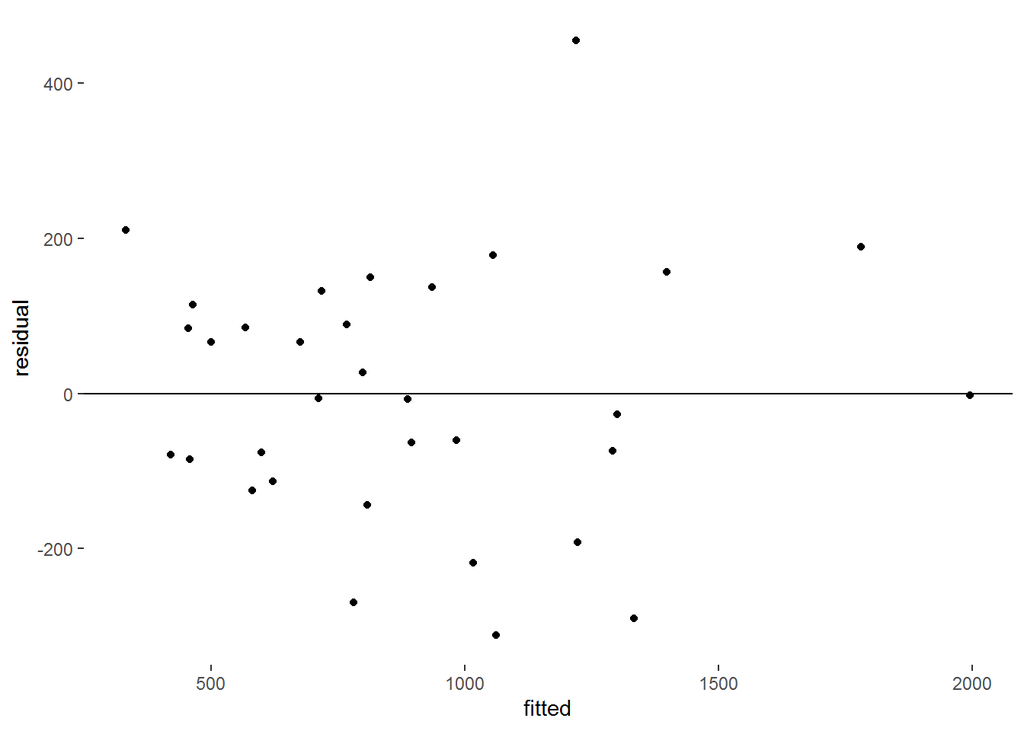

```r
resact <- data.frame(residual = model_backward_sig$residuals,
                     fitted = model_backward_sig$fitted.values)

resact %>% ggplot(aes(fitted, residual)) + geom_point() + geom_hline(aes(yintercept = 0)) +
    theme(panel.grid = element_blank(), panel.background = element_blank())
```

Melalui uji visual, diketahui nilai residual menyebar acak dan tidak ada pola tertentu, sehingga residual disimpulkan memenuhi asumsi homoskedastisitas.

Secara formal, untuk mendeteksi gejala heteroskedastisitas, dapat digunakan uji Breusch-Pagan.

Breusch-Pagan hypothesis :

- H0: Homoscedasticity
- H1: Heteroscedasticity

```r
library(lmtest)
bptest(model_backward_sig)
```

```
#>
#>  studentized Breusch-Pagan test
#>
#> data:  model_backward_sig
#> BP = 11.579, df = 9, p-value = 0.2381
```

Didapatkan p-value = 0.2381 lebih besar dari alpha = 0.05, maka H0 gagal ditolak, sehingga disimpulkan residual bersifat homoskedastisitas.

## 4.3 Non Autokorelasi

```r
library(car)
set.seed(1)
durbinWatsonTest(model_backward_sig)
```

```
#>  lag Autocorrelation D-W Statistic p-value
#>    1      0.07469894      1.841523   0.622
#>  Alternative hypothesis: rho != 0
```

Melalui uji Durbin-Watson, diperoleh p-value = 0.622 lebih besar dari alpha = 0.05, maka gagal menolak H0, sehingga disimpulkan residual dalam model regresi tidak berkorelasi otomatis.

## 4.4 Non Multikolinearitas

```r
vif(model_backward_sig)
```

```
#>            percent_m       mean_education         police_exp60
#>             1.671434             4.221867             2.541909
#> labour_participation           m_per1000f         unemploy_m24
#>             3.682841             3.321822             4.096037
#>         unemploy_m39           inequality          time_prison
#>             4.297793             3.413640             1.718370
```

Dari nilai VIF variabel prediktor di atas, semuanya bernilai kurang dari 10, sehingga disimpulkan tidak terdapat multikolinearitas.

# 5 Simpulan

Variabel yang digunakan pada model akhir untuk mendeskripsikan variansi `crime_rate` adalah `percent_m`, `mean_education`, `police_exp60`, `labour_participation`, `m_per1000f`, `unemploy_m24`, `unemploy_m39`, `inequality`, dan `time_prison`. Model ini telah memenuhi uji asumsi klasik. Model akhir dapat ditulis dalam persamaan regresi sebagai berikut:

$$crime\_rate = -9471.069 + 11.252 * percent\_m + 22.617 * mean\_education + 9.667 * police\_exp60 \\- 3.034 * labour\_participation + 6.405 * m\_per1000f - 11.069 * unemploy\_m24 \\+ 17.352 * unemploy\_m39 + 5.650 * inequality + 14.612 * time\_prison$$
Model akhir memiliki adjusted r-square sebesar 78.92%, artinya variabel prediktor menggambarkan variansi variabel target (`crime_rate`) sebesar 78.92%, sisanya 21.08% dijelaskan oleh variabel lain diluar model. Nilai RMSE yang dihasilkan pada data train sebesar 162.04 dan pada data test sebesar 316.3251.